# Luke Grosvenor Introduction

by Luke Grosvenor

# About me, in a few sentences

Hi there! My name is Luke and I am a third year PhD student in the Department of Mental Health at the Johs Hopkins Bloomberg School of Public Health. I primarily study autism spectrum disorder (ASD) and the complex interactions between genetic and environmental risk factors for the condition. I have used R for a few years now and am currently learning Python for use with my dissertation. I am most interested in improving my data visualization skills with the help of this course, and hope to gain some experience with or knowledge about building websites and apps in Shiny. Outside of school and research, I like to hike, play tennis and explore the Baltimore food scene (huge Ekiben fan!).

# Five fun (or so I think) things

- I am ambidextrous, with both hands and feet (for any fellow futbolers out there)
- I hiked the 272-mile Long Trail in Vermont over 17 days during the summer of 2020. Here is a photo from the summit of Mount Mansfield, Vermont’s highest peak

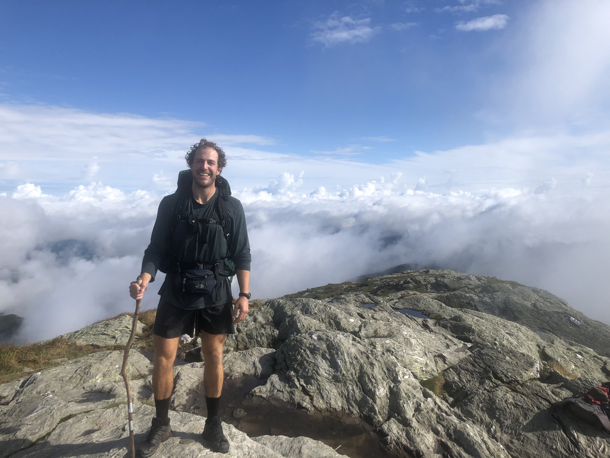

- I was pranked on the TV show, “Impractical Jokers” in New York City in the summer of 2013
- I am related to Orville Wright (of the Wright Brothers, first in flight)
- I can juggle just about anything (earlier in the pandemic featured juggling toilet paper rolls, if I could find any)

# Interesting Website

I like to browse Bloomberg’s CityLab website regularly. In particular, the “Environment” section is a favorite of mine, so here is a piece they wrote about why the NYC subway system floods so often (as it did when I was using it in early September during hurricane Ida). This is a problem that cities will continue to face as climate change brings more extreme rainfall. https://www.bloomberg.com/news/articles/2021-09-02/this-is-why-hurricane-ida-flooded-the-nyc-subway